# Dimention reduction

Bartłomiej Ramotowski

## Introduction

Dimension reduction simplifies complex datasets by keeping important information and eliminating unnecessary elements. By reducing the number of features, it not only facilitates faster computations but also allows for a clearer representation of the underlying structures, making it easier for machine learning models to do their work. Additionally with this method we can create more effective visualizations of our data.

Link to kaggle data set: https://www.kaggle.com/datasets/uom190346a/sleep-health-and-lifestyle-dataset

Dataset Columns descriptions form Kaggle:

Person ID: An identifier for each individual.

Gender: The gender of the person (Male/Female).

Age: The age of the person in years.

Occupation: The occupation or profession of the person.

Sleep Duration (hours): The number of hours the person sleeps per day.

Quality of Sleep (scale: 1-10): A subjective rating of the quality of sleep, ranging from 1 to 10.

Physical Activity Level (minutes/day): The number of minutes the person engages in physical activity daily.

Stress Level (scale: 1-10): A subjective rating of the stress level experienced by the person, ranging from 1 to 10.

BMI Category: The BMI category of the person (e.g., Underweight, Normal, Overweight).

Blood Pressure (systolic/diastolic): The blood pressure measurement of the person, indicated as systolic pressure over diastolic pressure.

Heart Rate (bpm): The resting heart rate of the person in beats per minute. Daily Steps: The number of steps the person takes per day.

Sleep Disorder: The presence or absence of a sleep disorder in the person (None, Insomnia, Sleep Apnea).

### Reading data

```r
health<-read.csv("Sleep_health_and_lifestyle_dataset.csv")
health<-health[,c(2:13)]
```

### Converting data to apropriete datatype

```r
#converting chr to factor
health$Gender<-as.factor(health$Gender)
health$Occupation<-as.factor(health$Occupation)
health$BMI.Category<-as.factor(health$BMI.Category)
health$Blood.Pressure <-as.factor(health$Blood.Pressure)
health$Sleep.Disorder  <-as.factor(health$Sleep.Disorder)

#converting factor to numeric
health$Gender<-as.numeric(health$Gender)
health$Occupation<-as.numeric(health$Occupation)
health$BMI.Category<-as.numeric(health$BMI.Category)
health$Blood.Pressure <-as.numeric(health$Blood.Pressure)
health$Sleep.Disorder  <-as.numeric(health$Sleep.Disorder)

health_scaled<-scale(health)
```

### Variables plots

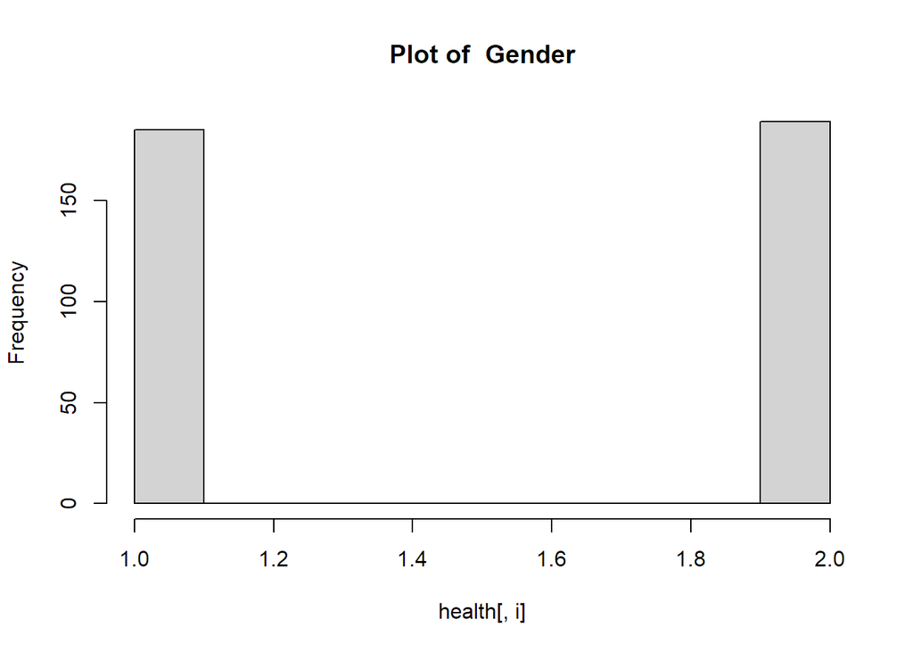

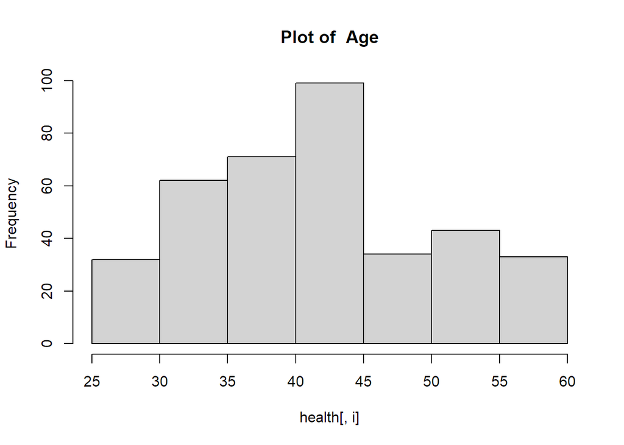

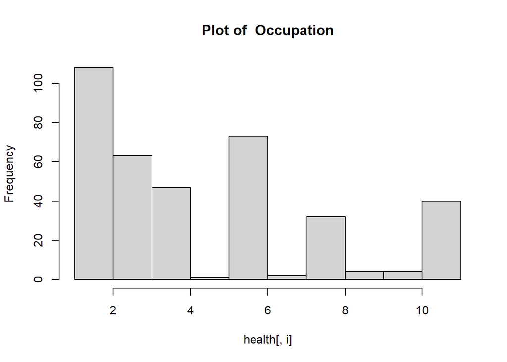

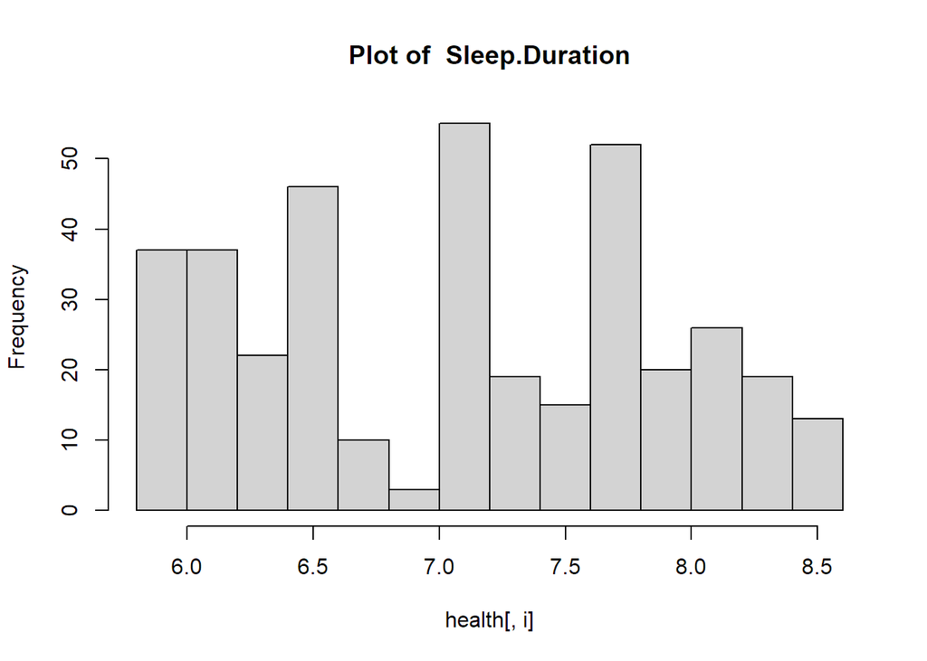

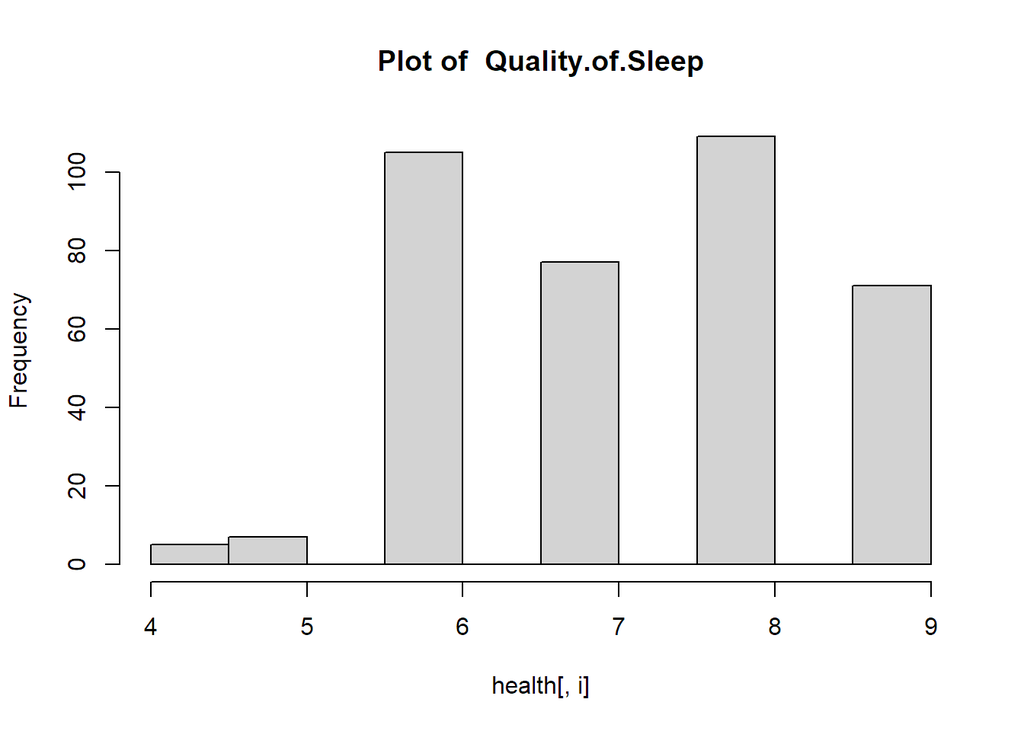

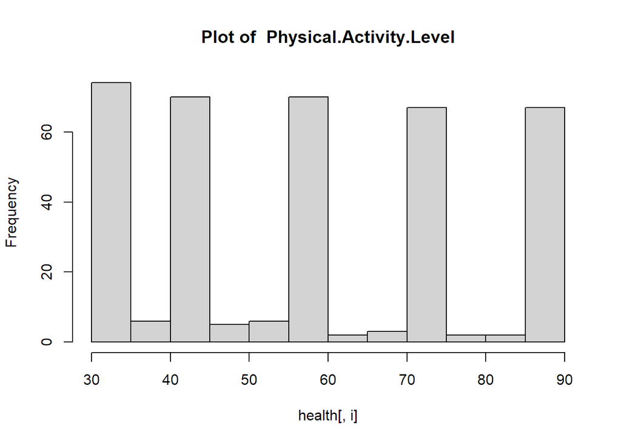

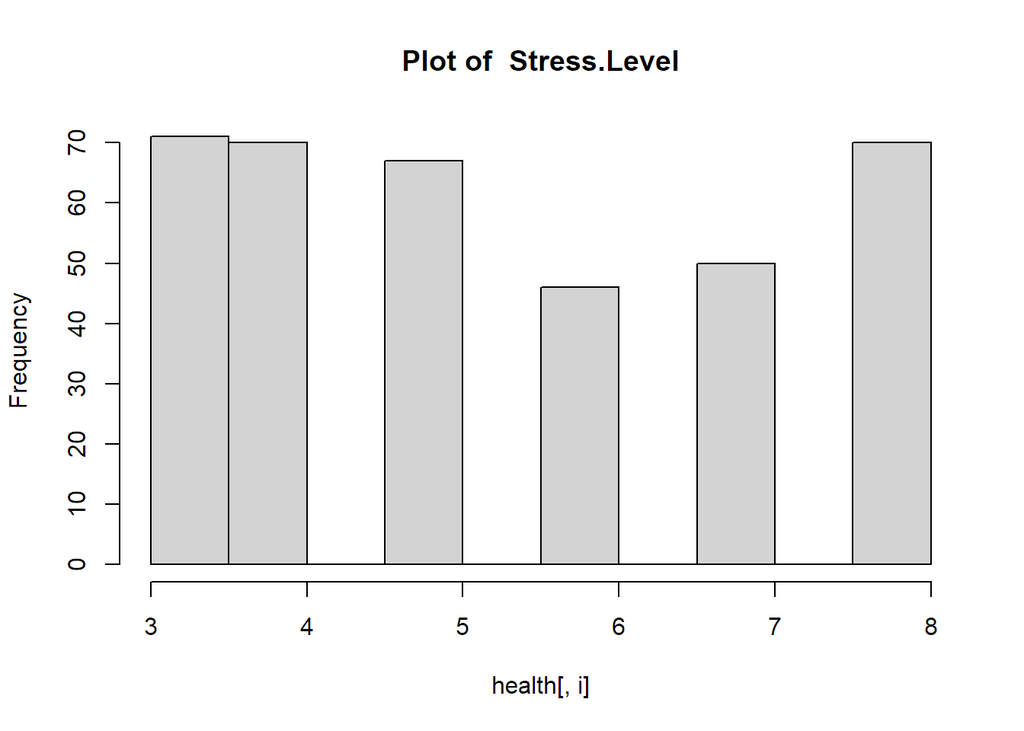

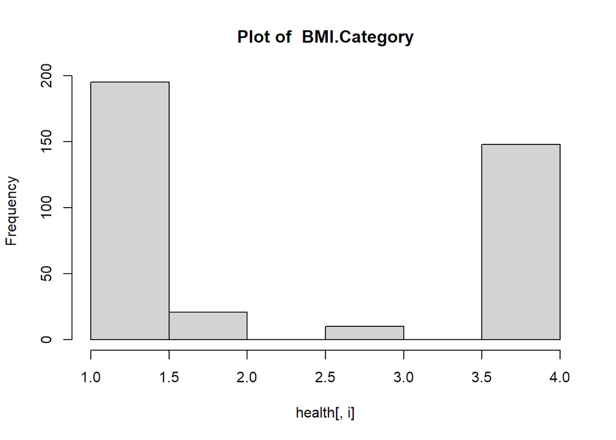

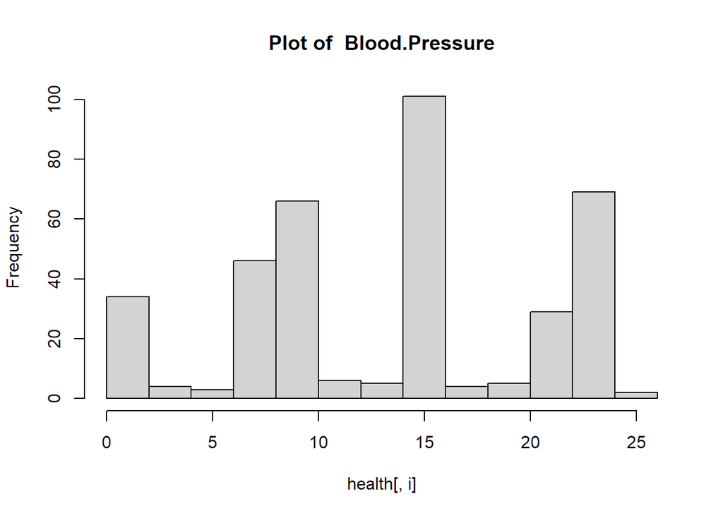

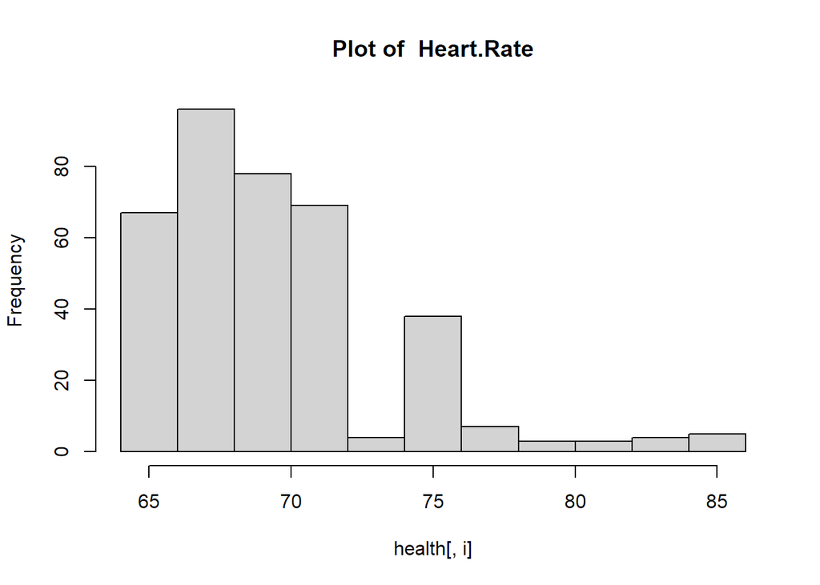

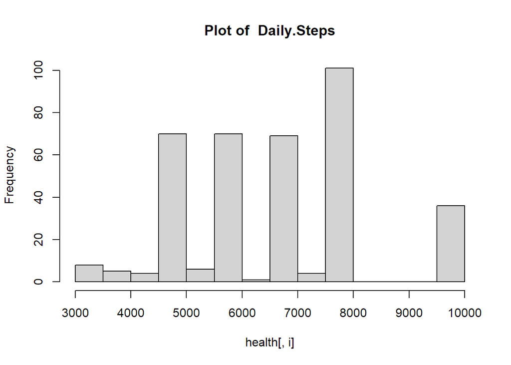

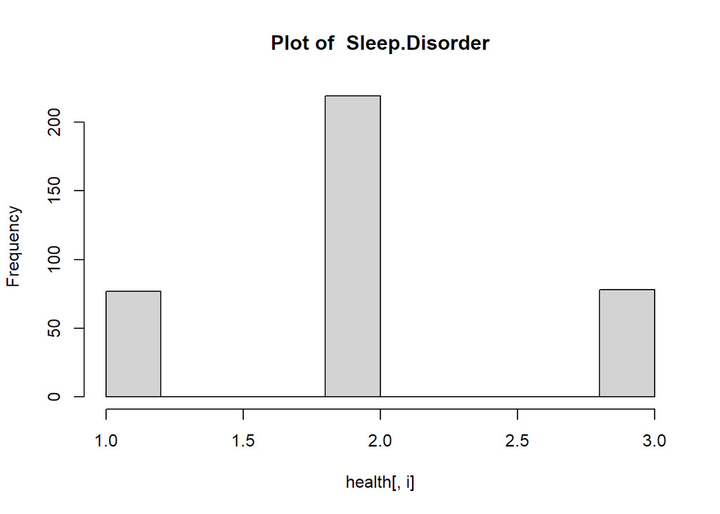

```r
for (i in colnames(health)) {
  hist(health[,i], main = paste("Plot of ", i))
}
```

### Correlation Matrix

```r
health.cor<-cor(health_scaled, method="pearson")
print(health.cor, digits=2)
```

```
##                          Gender    Age Occupation Sleep.Duration
## Gender                   1.0000 -0.596     -0.219          -0.12
## Age                     -0.5964  1.000      0.231           0.34
## Occupation              -0.2191  0.231      1.000          -0.33
## Sleep.Duration          -0.1216  0.345     -0.326           1.00
## Quality.of.Sleep        -0.2914  0.474     -0.278           0.88
## Physical.Activity.Level  0.0015  0.179     -0.104           0.21
## Stress.Level             0.3960 -0.422      0.021          -0.81
## BMI.Category            -0.3521  0.511      0.700          -0.38
## Blood.Pressure          -0.1763  0.573      0.547          -0.19
## Heart.Rate               0.2171 -0.226      0.044          -0.52
## Daily.Steps             -0.0145  0.058     -0.106          -0.04
## Sleep.Disorder          -0.2534  0.232     -0.170           0.18
##                         Quality.of.Sleep Physical.Activity.Level Stress.Level
## Gender                            -0.291                  0.0015        0.396
## Age                                0.474                  0.1790       -0.422
## Occupation                        -0.278                 -0.1037        0.021
## Sleep.Duration                     0.883                  0.2124       -0.811
## Quality.of.Sleep                   1.000                  0.1929       -0.899
## Physical.Activity.Level            0.193                  1.0000       -0.034
## Stress.Level                      -0.899                 -0.0341        1.000
## BMI.Category                      -0.313                  0.0772        0.164
## Blood.Pressure                    -0.148                  0.2719        0.118
## Heart.Rate                        -0.660                  0.1370        0.670
## Daily.Steps                        0.017                  0.7727        0.187
## Sleep.Disorder                     0.180                  0.4332       -0.036
##                         BMI.Category Blood.Pressure Heart.Rate Daily.Steps
## Gender                       -0.3521          -0.18      0.217     -0.0145
## Age                           0.5113           0.57     -0.226      0.0580
## Occupation                    0.6995           0.55      0.044     -0.1059
## Sleep.Duration               -0.3764          -0.19     -0.516     -0.0395
## Quality.of.Sleep             -0.3126          -0.15     -0.660      0.0168
## Physical.Activity.Level       0.0772           0.27      0.137      0.7727
## Stress.Level                  0.1639           0.12      0.670      0.1868
## BMI.Category                  1.0000           0.72      0.296     -0.0051
## Blood.Pressure                0.7242           1.00      0.288      0.1195
## Heart.Rate                    0.2956           0.29      1.000     -0.0303
## Daily.Steps                  -0.0051           0.12     -0.030      1.0000
## Sleep.Disorder                0.0166           0.20      0.206      0.3421
##                         Sleep.Disorder
## Gender                          -0.253
## Age                              0.232
## Occupation                      -0.170
## Sleep.Duration                   0.178
## Quality.of.Sleep                 0.180
## Physical.Activity.Level          0.433
## Stress.Level                    -0.036
## BMI.Category                     0.017
## Blood.Pressure                   0.198
## Heart.Rate                       0.206
## Daily.Steps                      0.342
## Sleep.Disorder                   1.000
```

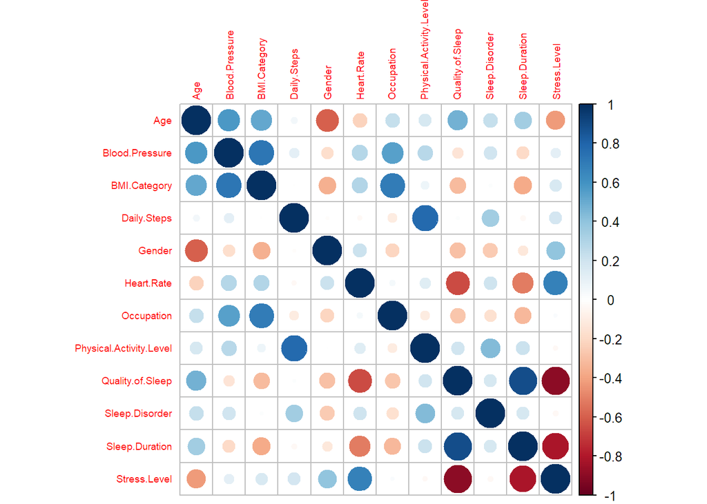

```r
corrplot(health.cor, order ="alphabet", tl.cex=0.6)
```

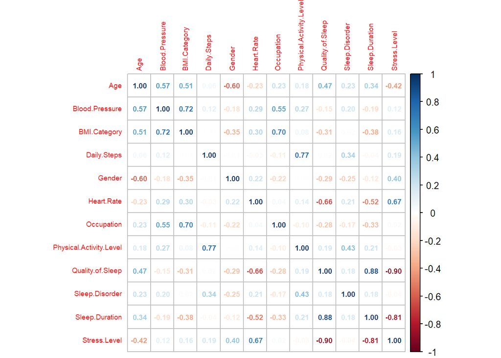

```r
corrplot(health.cor,method = "number", order ="alphabet", tl.cex=0.6,number.cex = 0.6)
```

In the dataset, we observe some positively correlated variables. There is a high correlation between the quality of sleep and sleep duration, as well as between daily steps and physical activity level. Additionally, we can identify some negatively correlated variables, such as the quality of sleep and stress level, or stress level and sleep duration.

## Dimension reduction

Before engaging in dimension reduction with PCA, let’s explore the outcomes of utilizing Multidimensional Scaling (MDS)

### MDS

```r
dist.health<-dist(t(health_scaled))
mds1<-cmdscale(dist.health)
summary(mds1)
```

```
##        V1                V2
##  Min.   :-19.024   Min.   :-13.606
##  1st Qu.: -5.169   1st Qu.:-10.641
##  Median :  1.559   Median :  3.539
##  Mean   :  0.000   Mean   :  0.000
##  3rd Qu.:  6.619   3rd Qu.:  6.143
##  Max.   : 17.328   Max.   : 14.365
```

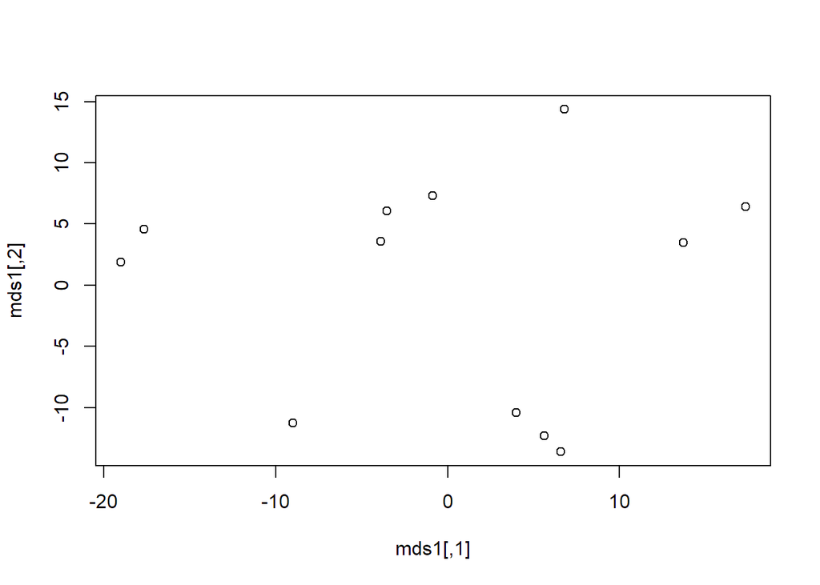

```r
plot(mds1)
```

```r
head(mds1)
```

```
##                               [,1]       [,2]
## Gender                    6.803646  14.364749
## Age                      -8.998869 -11.261713
## Occupation                5.606439 -12.320024
## Sleep.Duration          -17.677334   4.553004
## Quality.of.Sleep        -19.024445   1.877434
## Physical.Activity.Level  -3.543141   6.057680
```

We have indeed received some appropriately dimension-reduced data, but the main component of this project relies on PCA.

### PCA

```r
pca = prcomp(health_scaled, center=FALSE, scale=FALSE)
```

#### Choosing number of components

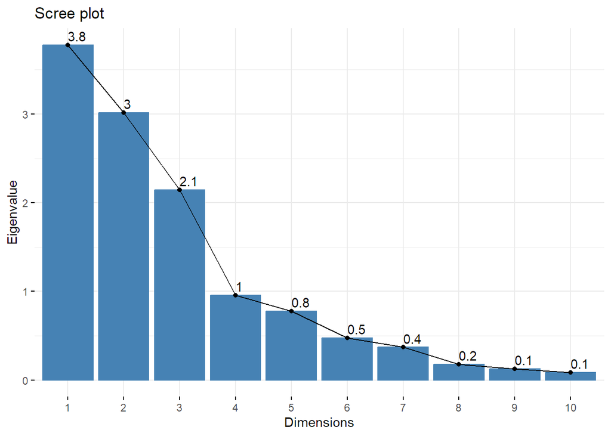

```r
fviz_eig(pca, choice = "eigenvalue",  addlabels = TRUE)
```

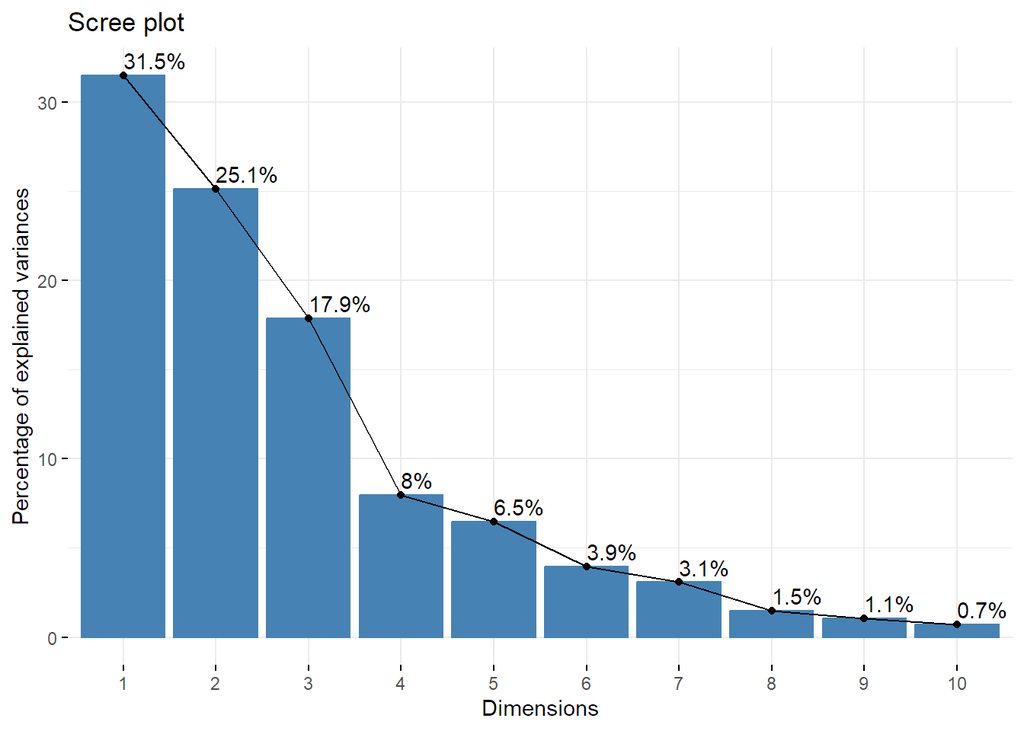

```r
fviz_eig(pca, choice = 'variance', addlabels = TRUE)
```

```r
summary(pca)
```

```
## Importance of components:
##                           PC1    PC2    PC3     PC4     PC5     PC6     PC7
## Standard deviation     1.9444 1.7371 1.4650 0.97708 0.88092 0.68839 0.60770
## Proportion of Variance 0.3151 0.2515 0.1788 0.07956 0.06467 0.03949 0.03077
## Cumulative Proportion  0.3151 0.5665 0.7453 0.82491 0.88958 0.92907 0.95984
##                            PC8    PC9    PC10    PC11    PC12
## Standard deviation     0.42130 0.3566 0.29247 0.25711 0.15991
## Proportion of Variance 0.01479 0.0106 0.00713 0.00551 0.00213
## Cumulative Proportion  0.97463 0.9852 0.99236 0.99787 1.00000
```

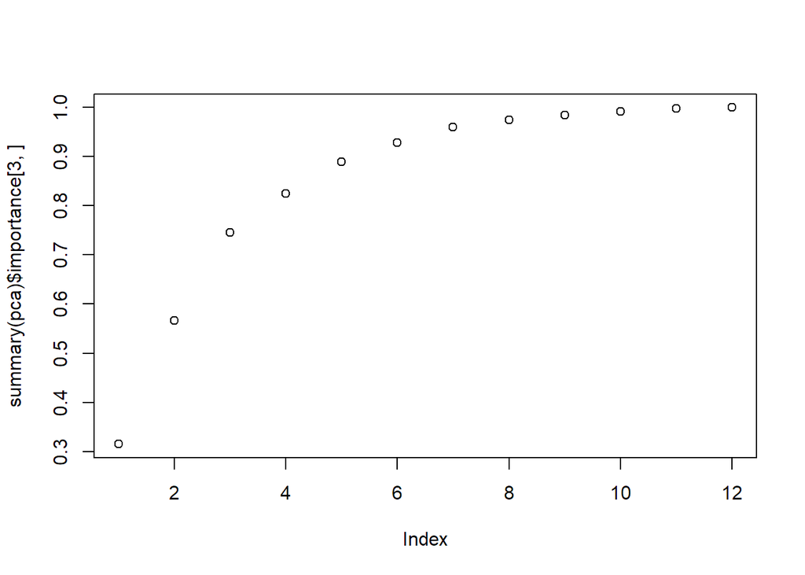

```r
plot(summary(pca)$importance[3,])
```

From the graphs we can see that 4 components explains over 80% of variation.

#### Variables PCA plot

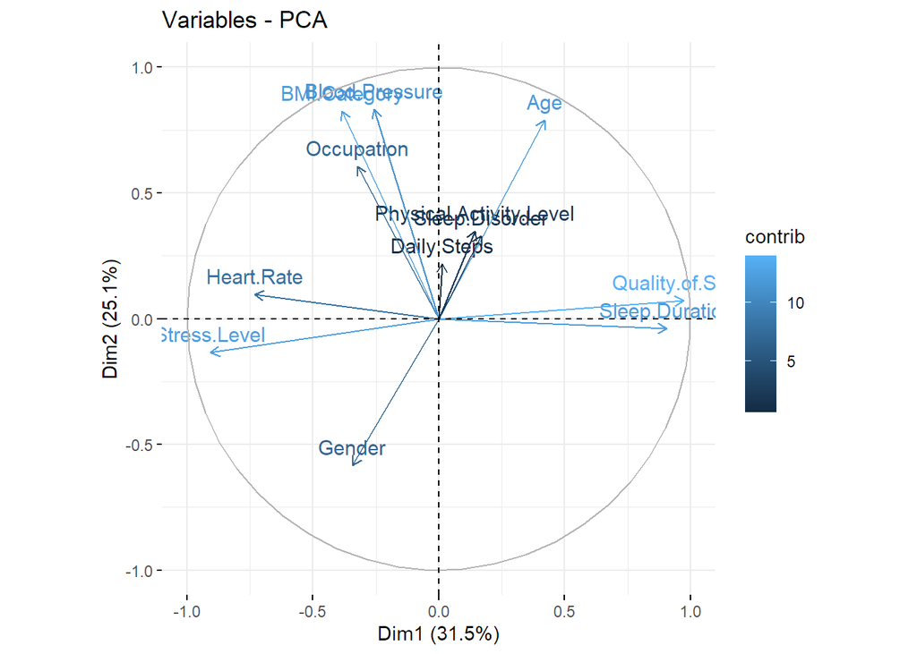

```r
fviz_pca_var(pca, col.var="contrib")
```

#### Individuals PCA plot

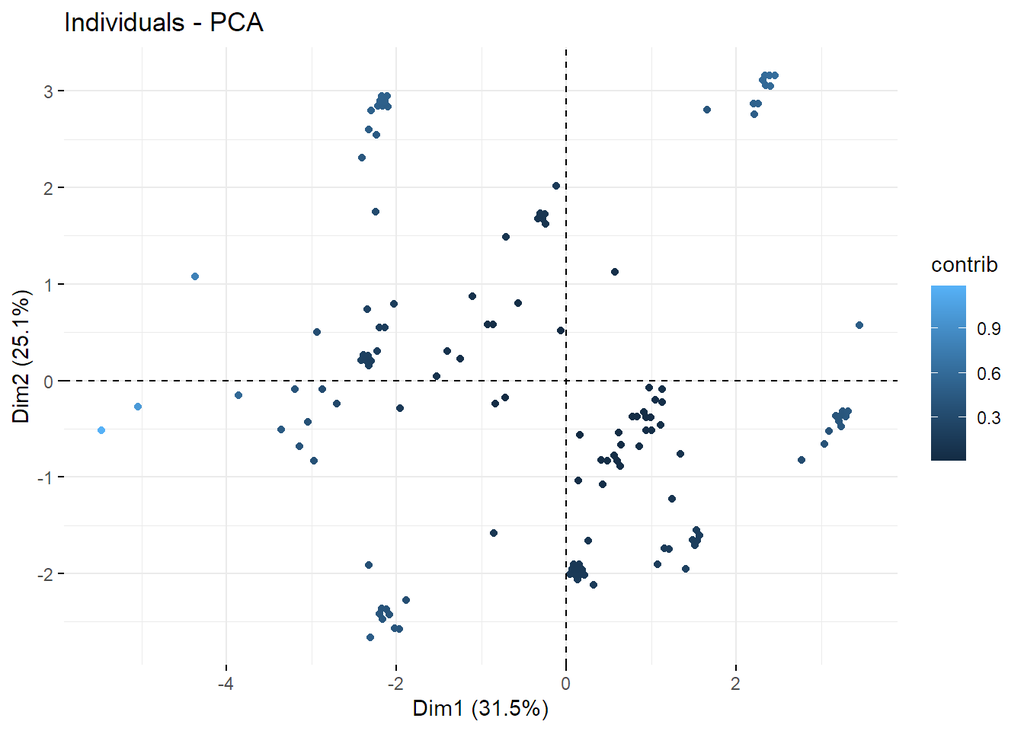

```r
fviz_pca_ind(pca, col.ind="contrib", geom = "point")
```

#### Contribution of variables

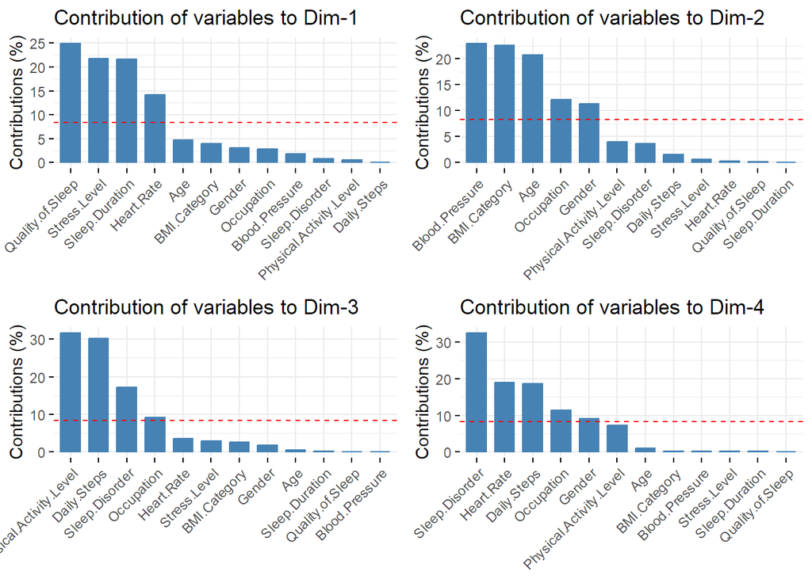

```r
PC1 <- fviz_contrib(pca, choice = "var", axes = 1)
PC2 <- fviz_contrib(pca, choice = "var", axes = 2)
PC3 <- fviz_contrib(pca, choice = "var", axes = 3)
PC4 <- fviz_contrib(pca, choice = "var", axes = 4)

grid.arrange(PC1, PC2, PC3, PC4, ncol = 2, nrow=2)
```

## Conclusions

The dimensions of our health dataset were effectively reduced using the PCA. The analysis indicate that our health data can be represented by 4 components. This allowed us to explain more than 80% of the dataset variance.